# Image Classification: NASA Mars Image Library

The images used for this neural network application are taken from NASA's Open Data Portal.

https://data.nasa.gov/Space-Science/Mars-orbital-image-HiRISE-labeled-data-set-version/egmv-36wq

**Mars orbital image (HiRISE) labeled data set version 3.2.0**  
(Citation: DOI: 10.5281/zenodo.4002935)

This dataset contains a total of 64,947 landmark images that were detected and extracted from HiRISE browse images, spanning 232 separate source images.

This set was formed from 10,815 original landmarks. Each original landmark was cropped to a square bounding box that included the full extent of the landmark plus a 30-pixel margin to the left, right, top, and bottom. Each landmark was then resized to 227x227 pixels. 9,022 of these images were then augmented to generate 6 additional landmarks using the following methods:

1. 90 degrees clockwise rotation
2. 180 degrees clockwise rotation
3. 270 degrees clockwise rotation
4. Horizontal flip
5. Vertical flip
6. Random brightness adjustment

The remaining 1,793 images were not augmented. Combining these with the 7*9,022 images, gives a total of 64,947 separate images.

We will follow the tutorial provided by Tensor Flow on [**Image Classification**](https://www.tensorflow.org/tutorials/images/classification), and incorporate Nachiketa Hebbar's advice from his YouTube video, [**"Transfer Learning Using Keras(ResNet-50)| Complete Python Tutorial"**](https://www.youtube.com/watch?v=JcU72smpLJk).

Normally, we should hit the site through code and download from the URL directly. This is a rather large dataset and it will require some manipulation. So, we download it directly, and we create the sub-directories as discussed in the tutorial.

Now, we try it - the download and ds creation directly. (There are some hiccups.)

- 1 - Packages
- 2 - Load and Process the Dataset
  - Additional manual processing required
  - Examine photos
- 3 - Loading data using a Keras utility
  - Create a dataset
  - Examine data elements in project store
- 4 - Fine-Tuning the ResNet50 Model
  - Save our model
  - Evaluating the model: Check model training over epochs
- 5 - Performance Evaluation
- 6 - Concluding Remarks

## 1 - Packages

Begin by importing all the packages you'll need during this assignment.

- [numpy](https://www.numpy.org/) is the fundamental package for scientific computing with Python.
- [matplotlib](http://matplotlib.org) is a library to plot graphs in Python.
- [h5py](http://www.h5py.org) is a common package to interact with a dataset that is stored on an H5 file.
- [PIL](http://www.pythonware.com/products/pil/)

```python
import matplotlib.pyplot as plt
import numpy as np
import os
import pathlib
import PIL
import tensorflow as tf

#TensorFlow tutorial imports
from tensorflow import keras
from tensorflow.keras import layers
from tensorflow.keras.models import Sequential

#TensorFlow tutorial from Nachiketa Hebbar - much aligned with the TdensorFlow tutorial
from tensorflow.keras.models import Model
from tensorflow.keras.layers import Conv2D, Flatten, Dense, MaxPool2D, BatchNormalization, GlobalAveragePooling2D
from tensorflow.keras.preprocessing import image
from tensorflow.keras.preprocessing.image import ImageDataGenerator, load_img
from tensorflow.keras.applications.resnet50 import ResNet50, preprocess_input, decode_predictions
from tensorflow.keras.applications import MobileNetV2
```

## 2 - Load and Process the Dataset

Let's get more familiar with the dataset. Load the data by running the cell below.

```python
import shutil

cwd = os.getcwd()
image_dir=os.path.join(cwd,"map-proj-v3_2")
print(image_dir)


dataset_url="https://zenodo.org/record/4002935/files/hirise-map-proj-v3_2.zip"
download_dir=tf.keras.utils.get_file(
    fname=os.path.join(cwd,'map-proj-v3_2.zip'),
    origin=dataset_url,
    cache_dir=os.path.join(cwd,'..'),
    cache_subdir=cwd,
    extract=True,
    archive_format='zip')

download_dir=pathlib.Path(download_dir)
#The 3.2 zipfile has the photos buried two layers deep, and the os library doesn't allow
#killing removing the '__MACOSX' extraneous subfolder, nor moving multiple files easily.
#Must be done manually.
```

### Additional manual processing required.

1. Kill "__MACOSX" subdirectory from extraction.
2. Move all contents from the extracted subfolder "hirise-map-proj-v3_2" to sit off of cwd node.
3. Now, kill the hirise-map-proj-v3_2 subfolder.

(This brings us back to the original v3.0 download format.)

```python
# Now, move the xref files into the current photos subdirectory.  This will have them at the top of download again once
# the the photos are all moved into their proper training, validation and test subfolders.

shutil.move(
    os.path.join(cwd,"landmarks_map-proj-v3_2_classmap.csv"),
    os.path.join(image_dir,"landmarks_map-proj-v3_2_classmap.csv"))
shutil.move(
    os.path.join(cwd,"labels-map-proj_v3_2_train_val_test.txt"),
    os.path.join(image_dir,"labels-map-proj_v3_2_train_val_test.txt"))
```

### Examine photos

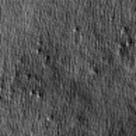

```python
photo_idx=0

download_dir=pathlib.Path(image_dir)
mars=list(download_dir.glob('*.jpg'))
PIL.Image.open(str(mars[photo_idx]))
```

```python
import shutil

cwd = os.getcwd()
image_dir=os.path.join(cwd,"map-proj-v3_2")
print(image_dir)

fh_landmarks=open(os.path.join(image_dir,"landmarks_map-proj-v3_2_classmap.csv"))
dict_landmarks={}
for line in fh_landmarks:
    label, landmark = line.rstrip().split(",")
    print(label, landmark)
    dict_landmarks[label]=landmark.replace(" ","_")
print(dict_landmarks)
fh_landmarks.close()

fh_labels=open(os.path.join(image_dir,"labels-map-proj_v3_2_train_val_test.txt"))
dict_fileLabels={}
dict_fileSamples={}
for line in fh_labels:
    fname, label, sample = line.rstrip().split(" ")
    dict_fileLabels[fname]=label
    dict_fileSamples[fname]=sample
    if not os.path.exists(os.path.join(image_dir,dict_fileSamples[fname])):
        os.mkdir(os.path.join(image_dir,dict_fileSamples[fname]))
    if not os.path.exists(os.path.join(image_dir,dict_fileSamples[fname],dict_landmarks[label])):
        os.mkdir(os.path.join(image_dir,dict_fileSamples[fname],dict_landmarks[label]))

print(list(dict_fileLabels.items())[:9])
print(list(dict_fileSamples.items())[:9])
fh_labels.close()


move_count=0
for f in os.listdir(image_dir):
    if f in dict_fileLabels.keys() and os.path.exists(os.path.join(image_dir,f)):

        sample = dict_fileSamples[f]
        label=dict_fileLabels[f]
        landmark=dict_landmarks[label]

        src_path=os.path.join(image_dir,f)
        dest_path=os.path.join(image_dir,sample,landmark,f)

        try:
            shutil.move(src_path,dest_path)
            move_count+=1
            print("Moved image".move_count)
        except FileNotFoundError:
            print("Could not find ", src_path)
            continue
        except:
            print("Other error occurred when attempting to access ", f)
            continue
```

## 3 - Load data using a Keras utility

Let's load these images off disk using the helpful tf.keras.utils.image_dataset_from_directory utility. This will take you from a directory of images on disk to a tf.data.Dataset in just a couple lines of code. If you like, you can also write your own data loading code from scratch by visiting the Load and preprocess images tutorial.

### Create a dataset

Define some parameters for the loader:

```python
batch_size = 32
#img_height = 227
#img_width = 227

#Not scaling down from original photo sizes overtaxed my processor.
img_height = 130
img_width = 130
```

```python
cwd = os.getcwd()
image_dir=os.path.join(cwd,"map-proj-v3_2")

train_data_dir=os.path.join(image_dir,"train")
val_data_dir=os.path.join(image_dir,"val")
test_data_dir=os.path.join(image_dir,"test")

#Let's follow Nachiketa Hebbar's recipe for performing this work.
train_ds = tf.keras.preprocessing.image_dataset_from_directory(
    directory=train_data_dir,
    #subset="training",
    seed=123,
    label_mode="categorical",
    #color_mode="grayscale",
    image_size=(img_height,img_width),
    batch_size=batch_size
)

val_ds = tf.keras.preprocessing.image_dataset_from_directory(
    directory=val_data_dir,
    #subset="validation",
    seed=123,
    label_mode="categorical",
    #color_mode="grayscale",
    image_size=(img_height,img_width),
    batch_size=batch_size
)

test_ds = tf.keras.preprocessing.image_dataset_from_directory(
    directory=test_data_dir,
    #subset="test",
    seed=123,
    label_mode="categorical",
    #color_mode="grayscale",
    image_size=(img_height,img_width),
    batch_size=batch_size
)

class_names = train_ds.class_names
print(class_names)
#We will not be using full implementation of ImageDataGenerator in this exercise,
#because the NASA data has already been processed this way.
```

```
Found 48979 files belonging to 8 classes.
Found 14175 files belonging to 8 classes.
Found 1793 files belonging to 8 classes.
['bright_dune', 'crater', 'dark_dune', 'impact_ejecta', 'other', 'slope_streak', 'spider', 'swiss_cheese']
```

### Examine data elements in project store

One last look before modeling begins.

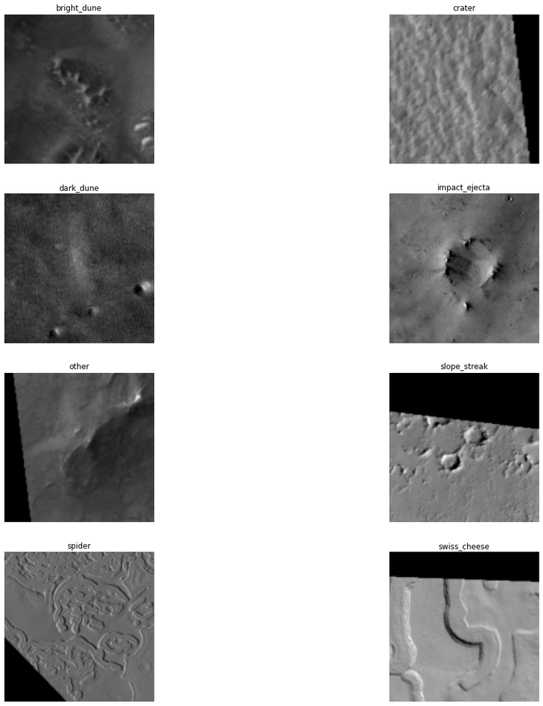

```python
#Let's view a few of these photos once more
import matplotlib.pyplot as plt

plt.figure(figsize=(20, 20))
for images, labels in train_ds.take(1):
  for i in range(8):
    ax = plt.subplot(4, 2, i + 1)
    plt.imshow(images[i].numpy().astype("uint8"))
    plt.title(class_names[i])
    plt.axis("off")
```

## 4 - Fine-Tuning the ResNet50 Model

Here we bring in th eResNet50 model as an untrainable base-model, removing its last layer, and adding a couple of our own layers that we *will train* for our eight classes.

```python
resnet_model = Sequential()

pretrained_model = ResNet50(include_top=False,
                            #pooling="avg", classes=len(class_names),
                            weights="imagenet")
for layer in pretrained_model.layers:
    layer.trainable=False

resnet_model.add(pretrained_model)
resnet_model.add(GlobalAveragePooling2D())
resnet_model.add(Dense(32, activation="relu")) #128, 256, 512, 1024 max'd out my laptop
resnet_model.add(Dense(len(class_names), activation="softmax"))

resnet_model.summary()
```

```
Model: "sequential_9"
_________________________________________________________________
Layer (type)                 Output Shape              Param #
=================================================================
resnet50 (Functional)        (None, None, None, 2048)  23587712
_________________________________________________________________
global_average_pooling2d_6 ( (None, 2048)              0
_________________________________________________________________
dense_16 (Dense)             (None, 32)                65568
_________________________________________________________________
dense_17 (Dense)             (None, 8)                 264
=================================================================
Total params: 23,653,544
Trainable params: 65,832
Non-trainable params: 23,587,712
_________________________________________________________________
```

```python
resnet_model.compile(
    optimizer=tf.keras.optimizers.Adam(learning_rate=0.001),
    loss="categorical_crossentropy",
    metrics=["accuracy"])

epochs=10
history = resnet_model.fit(
    train_ds,
    validation_data=val_ds,
    epochs=epochs,
    verbose=2)
```

```
1531/1531 - 5474s - loss: 0.2182 - accuracy: 0.9324 - val_loss: 0.3702 - val_accuracy: 0.8886
1531/1531 - 1786s - loss: 0.1234 - accuracy: 0.9572 - val_loss: 0.4171 - val_accuracy: 0.8851
1531/1531 - 3901s - loss: 0.0989 - accuracy: 0.9647 - val_loss: 0.4048 - val_accuracy: 0.8890
1531/1531 - 3537s - loss: 0.0840 - accuracy: 0.9696 - val_loss: 0.4479 - val_accuracy: 0.8906
1531/1531 - 1783s - loss: 0.0731 - accuracy: 0.9733 - val_loss: 0.4483 - val_accuracy: 0.8937
1531/1531 - 8731s - loss: 0.0651 - accuracy: 0.9763 - val_loss: 0.4927 - val_accuracy: 0.8914
1531/1531 - 3710s - loss: 0.0584 - accuracy: 0.9786 - val_loss: 0.5510 - val_accuracy: 0.8892
1531/1531 - 1594s - loss: 0.0515 - accuracy: 0.9806 - val_loss: 0.5745 - val_accuracy: 0.8880
1531/1531 - 2753s - loss: 0.0476 - accuracy: 0.9820 - val_loss: 0.5536 - val_accuracy: 0.8837
1531/1531 - 1729s - loss: 0.0443 - accuracy: 0.9834 - val_loss: 0.6546 - val_accuracy: 0.8899
```

### Save our model

We save this model in h5 format now.

```python
resnet_model.save("./ResNet50_MarsNN_wk7.h5")
```

### Evaluating the model: Check model training over epochs

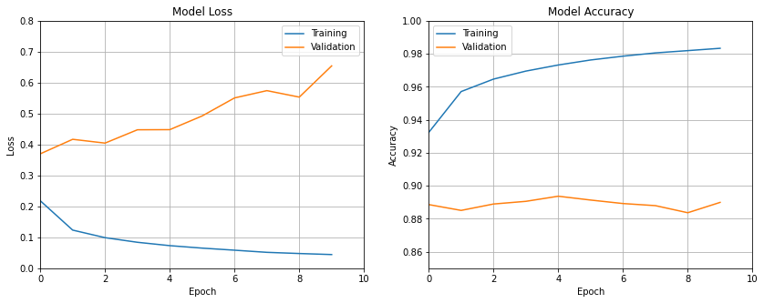

```python
fig, (ax1, ax2) = plt.subplots(1,2,figsize=(14,5))
ax1.plot(history.history['loss'], label="Training")
ax1.plot(history.history['val_loss'], label="Validation")
ax1.set_xlabel("Epoch")
ax1.set_ylabel("Loss")
ax1.set_title("Model Loss")
ax1.axis([0,10,0.0,0.8])
ax1.grid(True)
ax1.legend()
ax2.plot(history.history['accuracy'], label="Training")
ax2.plot(history.history['val_accuracy'], label="Validation")
ax2.set_xlabel("Epoch")
ax2.set_ylabel("Accuracy")
ax2.set_title("Model Accuracy")
ax2.axis([0,10,0.85,1.0])
ax2.grid(True)
ax2.legend();
```

So, it appears that Loss increases for the validation sample as the number of epochs increase; yet, accuracy is fairly steady over the range. In fact, it seems that running for merely 4 epochs would have been a reasonable limit: validation accuracy is near its maximum over the range at 4 epaochs, and the loss function is only starting to climb at that that point.

Next, we will run predictions on the test sample and view performance via a confusion matrix (and calculate the accuracy of the model on the sample, too).

## 5 - Performance Visualization

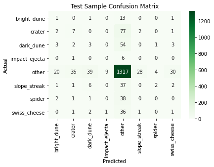

```
Test Sample Accuracy : 74.12
```

```python
import pandas as pd
import seaborn as sn

#resnet_model = tf.keras.models.load_model("./ResNet50_MarsNN_w7.h5")
def produce_confusion_matix(strSampleName, strSampleDSname):
    cwd = os.getcwd()
    imageDir=os.path.join(cwd,"map-proj-v3_2",strSampleName.lower())
    os.listdir(imageDir)

    lst_subfolders=os.listdir(imageDir)     # must rebuild the landmarks dictionary, since the tf.data.Datasets use the
    dict_subfolders={}                      # subfolder ordering in the project directory when estimating the model and
    for i in range(len(lst_subfolders)):    # backpropagating.
        dict_subfolders[str(i)]=lst_subfolders[i]


    #Get predictions list
    predictions_sample=resnet_model.predict(strSampleDSname)

    pred_classnames_sample=[]
    pred_class_sample=np.argmax(predictions_sample,axis=1)
    for i in range(len(pred_class_sample)):
        pred_classnames_sample.append(dict_subfolders[str(pred_class_sample[i])])

    #Get actuals list
    elem_class_sample=[]
    for elem in strSampleDSname:
        elem_class_sample.append(elem[1])
    actual_classvectors_sample=np.concatenate(elem_class_sample, axis=0)
    actual_class_sample=np.argmax(actual_classvectors_sample,axis=1)

    actual_classnames_sample=[]
    for i in range(len(actual_class_sample)):
        actual_classnames_sample.append(dict_subfolders[str(actual_class_sample[i])])

    out_df = pd.DataFrame(np.vstack([pred_classnames_sample,actual_classnames_sample]).T,columns=["predicted_class","actual_class"])
    confusion_matrix = pd.crosstab(out_df["actual_class"], out_df["predicted_class"], rownames=["Actual"], colnames=["Predicted"])

    mdl_accuracy = (len(out_df[out_df["predicted_class"]==out_df["actual_class"]])/confusion_matrix.sum().sum()*100)

    sn.heatmap(confusion_matrix, cmap="Greens", annot=True, fmt="d")
    plt.title(strSampleName+" Sample Confusion Matrix")
    plt.show()
    print(strSampleName+" Sample Accuracy : {:0.2f}".format(mdl_accuracy))


produce_confusion_matix(strSampleName="Test", strSampleDSname=test_ds)
```

## 6 - Concluding Remarks

So, the confusion matrix demonstrates one f the difficulties we are having with this particular version of the model. The "other" class dominates everything. The fact that it "other" --> "other" mappng by the model is heavy allows for the high accuarcy value. We see that elsewhere (eliminating the "other" class) there is a fair amount of misclassification with the model.

We had to trim the information in our data elements from (227, 227) to (130, 130), in order not to overwhelm the hardware on whch this code was run. So, this may be an area that we could focus on to remediate the model.

Also, in our last version submitted in week 2, we used the functional form of neural network building, which did not overwhelm the hardware, even though we had just as many parameters and more in that model, and we used the full image renditions as our sample points. Thus, it seems that the Sequential methodology in TensorFlow has some overhead that the functional forms do not. Sequential forms are easire to understand and build (for the novice like me), but it comes at a cost.